# Predicting genuine and forged banknotes

For this project, we will use the banknote authentication dataset from the OpenML platform. The banknote authentication dataset is about distinguishing genuine and forged banknotes. To produce this dataset, images were taken from both genuine and forged banknotes. Then a special tool, Wavelet Transform, was used to extract features from these images. These features are: variance, skewness, curtosis, and entropy of the images. We will use a simplified version of this dataset. There's only two features, V1 and V2.

```python
import pandas as pd
import matplotlib.pyplot as plt

data = pd.read_csv('Banknote-authentication-dataset.csv')
data.head()
```

|  | V1 | V2 |
| --- | --- | --- |
| 0 | 3.62160 | 8.6661 |
| 1 | 4.54590 | 8.1674 |
| 2 | 3.86600 | -2.6383 |
| 3 | 3.45660 | 9.5228 |
| 4 | 0.32924 | -4.4552 |

```python
data.describe()
```

|  | V1 | V2 |
| --- | --- | --- |
| count | 1372.000000 | 1372.000000 |
| mean | 0.433735 | 1.922353 |
| std | 2.842763 | 5.869047 |
| min | -7.042100 | -13.773100 |
| 25% | -1.773000 | -1.708200 |
| 50% | 0.496180 | 2.319650 |
| 75% | 2.821475 | 6.814625 |
| max | 6.824800 | 12.951600 |

The banknote authentication dataset has 1,372 instances and no missing values.

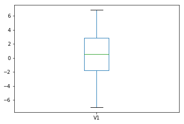

```python
data['V1'].plot.box()
```

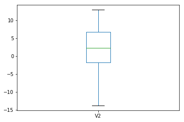

```python
data['V2'].plot.box()
```

To visualize the data we’ll be using the Scatter plot from matplotlib, which will allow us to make better analyses of the data.

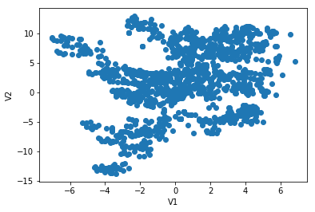

```python
plt.xlabel('V1')
plt.ylabel('V2')
plt.scatter(data['V1'], data['V2'])
```

It’s time for the next phase of your project: modeling, which means building or training a predictive model. A model to forecast outcomes. In our case, we want to use the banknote authentication dataset to train a model that can predict if a banknote is genuine or not.

The distribution in the graph seems not too spread and not too centered, and the number of instances seems to be sufficient, which means worth to try the K-means clustering algorithm, despite the distribution shape isn’t spherical. Since the first feature varies between -7.04 to 6.82, while the other from -13.77 to 12.95, could be interesting to apply the same scale of measurements to both features, i.e, standardize the features before creating the model.

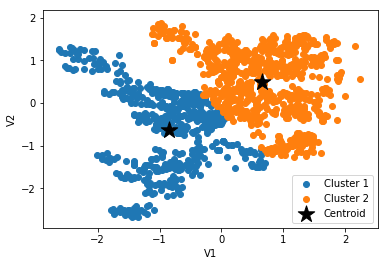

```python
from sklearn.preprocessing import StandardScaler
from sklearn.cluster import KMeans
import numpy as np

features = np.column_stack((data['V1'], data['V2']))
scaler = StandardScaler()
features_std = scaler.fit_transform(features)

cluster = KMeans(n_clusters=2, max_iter=100, n_jobs=-1)
model = cluster.fit(features_std)
cluster_centers = model.cluster_centers_

d = {'V1': features_std[:,0], 'V2': features_std[:,1]}
df = pd.DataFrame(data=d)
df['cluster'] = model.labels_

cluster1 = df[df['cluster'] == 1]
cluster0 = df[df['cluster'] == 0]

plt.xlabel('V1')
plt.ylabel('V2')
plt.scatter(cluster1.V1, cluster1.V2, label='Cluster 1')
plt.scatter(cluster0.V1, cluster0.V2, label='Cluster 2')
plt.scatter(cluster_centers[:,0], cluster_centers[:,1], s=300, marker='*', c='black', label='Centroid')
plt.legend(loc='lower right')
plt.show()
```

The K-means clustering algorithm starts the process of clustering by randomly choosing the initial positions of the centroids to calculate the points nearest the centroids, and then recalculate them. This random selection could be affecting the final results, so it’s essential to check if the algorithm is stable for the given dataset. To check the stability of the algorithm we’ll rerun it several times and check for significant differences in the final results.

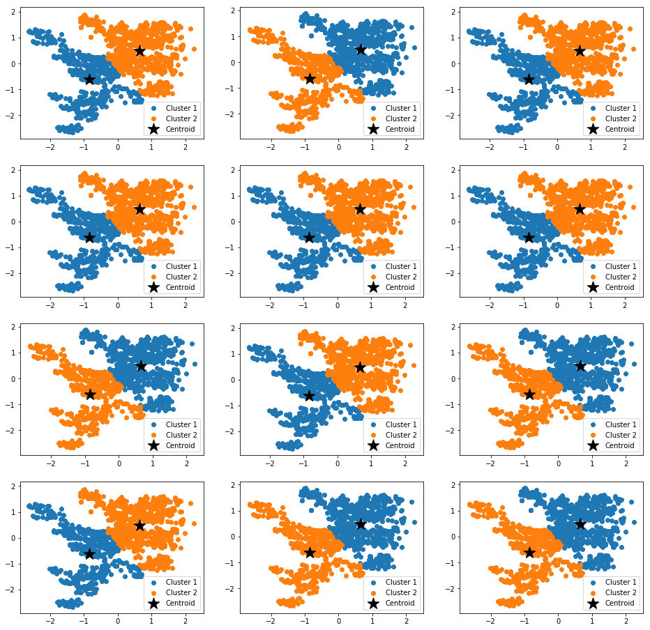

```python
n_iter = 12
_, graph = plt.subplots(4, 3, figsize=(16, 16))
graph = np.ravel(graph)

for i in range(n_iter):
    clusters = KMeans(n_clusters=2, max_iter=100)
    model = clusters.fit(features_std)
    centroids = model.cluster_centers_

    graph[i].scatter(df[model.labels_ == 0]['V1'], df[model.labels_ == 0]['V2'], label='Cluster 1')
    graph[i].scatter(df[model.labels_ == 1]['V1'], df[model.labels_ == 1]['V2'], label='Cluster 2')
    graph[i].scatter(centroids[:, 0], centroids[:, 1], c='black', marker='*', s=300, label='Centroid')
    graph[i].legend(loc='lower right')
```

```python
print('Number of points in cluster 1: ', df[df['cluster'] == 0].V1.count())
print('Number of points in cluster 2: ', df[df['cluster'] == 1].V1.count())
```

```
Number of points in cluster 1:  775
Number of points in cluster 2:  597
```

The best way to show that a model is good is to compare its predictions with real outcomes. We’ll compare predictions made by the model with the predictions in OpenML.

```python
result = pd.read_csv('bank_notes_results.csv')
result['class'] = result['class'].replace(1, 0)
result['class'] = result['class'].replace(2, 1)
```

```python
acc = df[df['cluster'] == result['class']].count() / df.shape[0]
print('Accuracy: ', acc.V1*100)
```

```
Accuracy:  87.82798833819243
```